# $\qquad$ Quem fala?

- Matemática Aplicada na UFRJ. 2 vezes.
- Mestrado antes de terminar a graduação.
- Ciência da Computação por uns semestres.
- Iniciação Científica que se tornou um desafio de mais de 2 anos.
- Muita atenção aos detalhes. Até com Lego.

# $\qquad$ O que será falado?

- Temos **Dados**. Queremos **Perspectiva**.
- Todavia, isso requer **bons** dados. Ou seja, precisa-se
  - **Tratar** os dados
  - **Viabilizar** o possível pós tratamento
- Feito isso
  - ou teremos **Respostas**
  - ou descoberto **Lacunas**

# $\quad$ Começa-se pela organização mental

### $\qquad$ Para fins de compreensão e exposição, a tabela foi organizada da seguinte forma:

$\qquad$ 1. Dividiu-se as colunas nos respectivos canais e marcas. Isso porque consegue-se ver melhor a correlação entre os dados nessa separação, útil para fins de reconstrução ou localização de anomalias e estruturas nelas.

$\qquad$ 2. Daí, as linhas da tabela são referenciadas por período de ocorrência. Como se tratam de dados temporais, ainda que com mais atributos, essa organização permite isolar uma potencial sazonalidade de eventos mais naturalmente.

Uma amostra da formatação da tabela:

```python
data_table.loc (axis=0)[3, :, Dates[:2]][Columns[:4]]
```

| Media | Brand | Date | Investment | NumVisits | NumUniqueVisits | GrossSalesEstimate |
| --- | --- | --- | --- | --- | --- | --- |
| 3 | 0 | 2015-07-01 | 594274.56 | 419272.0 | 188104.0 | 6777557.60 |
|  |  | 2015-07-02 | 2041522.56 | 598080.0 | 276206.0 | 12301457.52 |
|  | 1 | 2015-07-01 | 183924.40 | 62482.0 | 28994.0 | 1499860.56 |
|  |  | 2015-07-02 | 340737.76 | 119938.0 | 57750.0 | 2431011.44 |
|  | 2 | 2015-07-01 | 165946.00 | 69818.0 | 30814.0 | 2193018.96 |
|  |  | 2015-07-02 | 322920.40 | 115066.0 | 53592.0 | 2796456.08 |

# $\qquad$ O processo de análise seguirá assim:

$\qquad$ 1. Agrupar os canais por tipo de anomalia. Isso cria uma repartição clara nos tipos de KPI's possíveis para cada canal.

$\qquad$ 2. Para cada grupo são destrinchados e reportados potenciais fatores indicativos de desempenho de cada canal (por marca e cumulativo).

Dentre esses KPI's estão:

- Conversão de **investimentos** em **tráfego**
- Conversão de **visitas** em **volume** de vendas

Via:

- **Médias** e **volatilidades** (desvios padrões)
- Diferentes escalas de tempo (**Mensal, Trimestral**, etc)

# $\quad$ Após Inspeção dos dados, nota-se o seguinte:

## $\qquad$ Há anomalias de dois tipo distinguíveis:

$\qquad$ 1. Zeros e valores pequenos nas tabelas, de três tipos distinguíveis.

$\qquad$ 2. Valores negativos nas tabelas.

## $\qquad$ Zeros ou valores pequenos em diversas das colunas, para todas as datas.

$\qquad$ Mais especificamente, o canal '8' parece possuir quase todas as colunas anômalas nesse sentido. Assim sendo, a análise desses dados torna-se inviável e portanto esse canal será excluído da análise.

```python
all_zeros = [[media, brand] for media in Medias for brand in Brands
             if (data_table.loc[media, brand] < 1000).all (axis=0).all ()]

zero_anomalies += all_zeros
print ('    Canais e marcas com todas as entradas abaixo de 1000:\n')
print (''.join (('Canal {:d}, marca {:d};\n'.format (media, brand) for media, brand in all_zeros)))
```

```
    Canais e marcas com todas as entradas abaixo de 1000:

Canal 8, marca 0;
Canal 8, marca 2;
```

Uma amostra da anomalia:

```python
media, brand = all_zeros[0]
data_table.loc (axis=0)[media, brand, Dates[:2], :]
```

| Media | Brand | Date | Investment | NumVisits | NumUniqueVisits | GrossSalesEstimate | GrossSalesPlaced | GrossSalesApproved | QtyOrdersPlaced | QtyOrdersApproved |
| --- | --- | --- | --- | --- | --- | --- | --- | --- | --- | --- |
| 8 | 0 | 2015-07-01 | 0.0 | 0.0 | 0.0 | 0.0 | 0.0 | 0.0 | 0.0 | 0.0 |
|  |  | 2015-07-02 | 0.0 | 14.0 | 0.0 | 0.0 | 0.0 | 0.0 | 0.0 | 0.0 |

$\qquad$ A marca '1' não segue o critério da anomalia acima. No entanto, cairá nos mesmos critérios de anomalia do canal '9'. Segue uma amostra:

```python
media, brand = 8, 1
data_table.loc (axis=0)[media, brand, Dates[:2], :]
```

| Media | Brand | Date | Investment | NumVisits | NumUniqueVisits | GrossSalesEstimate | GrossSalesPlaced | GrossSalesApproved | QtyOrdersPlaced | QtyOrdersApproved |
| --- | --- | --- | --- | --- | --- | --- | --- | --- | --- | --- |
| 8 | 1 | 2015-07-01 | 0.0 | 0.0 | 0.0 | 48968567.12 | 74351990.24 | 48968567.12 | 237248.0 | 161040.0 |
|  |  | 2015-07-02 | 0.0 | 0.0 | 0.0 | 50421557.12 | 75087814.56 | 50421557.12 | 246840.0 | 164208.0 |

$\qquad$ O canal '9' possui anomalias nas colunas de Investimentos e Número de Visitas, únicas ou não.

```python
large_zeros = [[media, brand] for media in Medias for brand in Brands
               if [media, brand] not in treated_anomalies and
               (data_table.NumUniqueVisits.loc[media, brand] < data_table.QtyOrdersPlaced.loc[media, brand]).all ()]

zero_anomalies += large_zeros
print ('    Canais e marcas com todas as entradas de Investimentos e número de visitas, únicas ou não, abaixo de 1000:\n')
print (''.join (('Canal {:d}, marca {:d};\n'.format (media, brand) for media, brand in large_zeros)))
```

```
    Canais e marcas com todas as entradas de Investimentos e número de visitas, únicas ou não, abaixo de 1000:

Canal 8, marca 1;
Canal 9, marca 0;
Canal 9, marca 1;
Canal 9, marca 2;
```

$\qquad$ Conforme ressaltado antes, a marca '1' do canal '8' recai nesse critério de anomalia.

Segue uma amostra da anomalia no canal '9'.

```python
media, brand = 9, 0
data_table.loc (axis=0)[media, brand, Dates[:2], :]
```

| Media | Brand | Date | Investment | NumVisits | NumUniqueVisits | GrossSalesEstimate | GrossSalesPlaced | GrossSalesApproved | QtyOrdersPlaced | QtyOrdersApproved |
| --- | --- | --- | --- | --- | --- | --- | --- | --- | --- | --- |
| 9 | 0 | 2015-07-01 | 0.0 | 28.0 | 0.0 | 52268917.36 | 67507015.84 | 52268917.36 | 93456.0 | 77000.0 |
|  |  | 2015-07-02 | 0.0 | 0.0 | 0.0 | 43593076.56 | 60177736.08 | 43593076.56 | 90200.0 | 70576.0 |

## $\quad$ Viabilidade dos Indicadores

$\qquad$ Visto que não há colunas válidos para os canais '8' e '9' não há KPI relevante apresentável. Mesmo no caso do canal '9' ainda que as demais colunas possuam valores válidos não há indicador indireto de retorno disponível.

## $\qquad$ Zeros em toda coluna de investimentos, apenas nela

$\qquad$ Limita-se aos canais '2', '4' e '5' e não afeta a princípio as demais colunas.

```python
invest_zeros = [[media, brand] for media in Medias for brand in Brands
                if [media, brand] not in treated_anomalies and
                (data_table.Investment.loc[media, brand] < 1000).all ()]

zero_anomalies += invest_zeros
print ('    Canais e marcas com todas as entradas de Investimentos abaixo 1000:\n')
print (''.join (('Canal {:d}, marca {:d};\n'.format (media, brand) for media, brand in invest_zeros)))
```

```
    Canais e marcas com todas as entradas de Investimentos abaixo 1000:

Canal 2, marca 0;
Canal 2, marca 1;
Canal 2, marca 2;
Canal 4, marca 0;
Canal 4, marca 1;
Canal 4, marca 2;
Canal 5, marca 0;
Canal 5, marca 1;
Canal 5, marca 2;
```

Segue uma mostra da anomalia:

```python
media, brand = 2, 0
data_table.loc (axis=0)[media, brand, Dates[:2], :]
```

| Media | Brand | Date | Investment | NumVisits | NumUniqueVisits | GrossSalesEstimate | GrossSalesPlaced | GrossSalesApproved | QtyOrdersPlaced | QtyOrdersApproved |
| --- | --- | --- | --- | --- | --- | --- | --- | --- | --- | --- |
| 2 | 0 | 2015-07-01 | 0.0 | 8747844.0 | 2743034.0 | 2.055966e+08 | 3.206052e+08 | 2.055966e+08 | 728200.0 | 542960.0 |
|  |  | 2015-07-02 | 0.0 | 7400106.0 | 2183272.0 | 2.381483e+08 | 3.568971e+08 | 2.381483e+08 | 780736.0 | 586520.0 |

## $\quad$ Viabilidade dos Indicadores

$\qquad$ Ainda que não sejam anomalias recuperáveis, é possível avaliar os indicadores não relacionados a investimentos, como conversão de visitas em ordens e retorno.

Segue uma mostra dos indicadores para o canal '2':

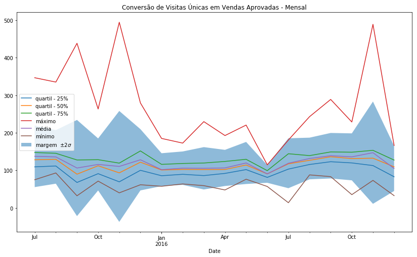

```python
describe_simple_plot (indicator_medias[media][1][period][sumary][base, output], indicator_title);
```

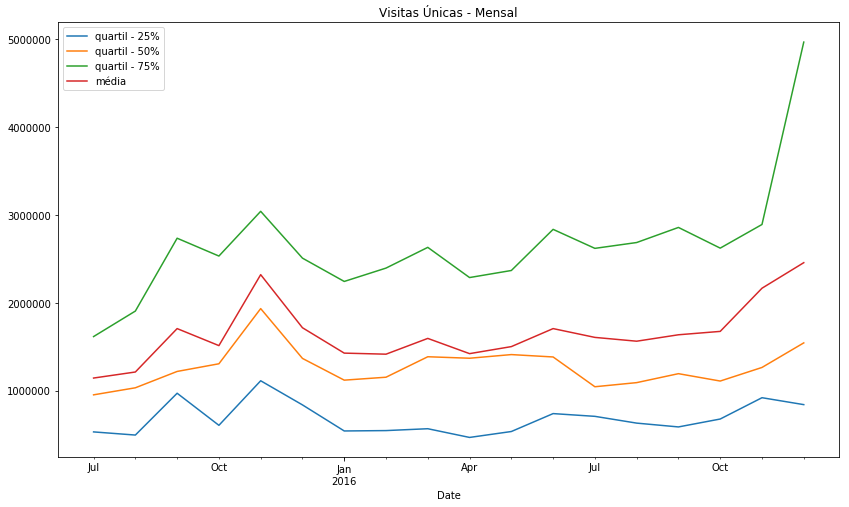

```python
data_table.index.set_levels (sumary_periods[period], level='Date', inplace=True)
describe_simple_plot (data_table.loc[media][base].groupby (level=-1).describe (), base_title,
                      non_extrm_plot_labels)
```

## $\qquad$ Sequências localizadas de zeros ou valores pequenos.

```
        Afetam os canais '0', '6' e '7' e ocorrem em trechos curtos e espalhados. Portanto, a princípio, podem ser apenas ignorados ou substituídos por uma regressão. Então será possível obter-se todas as estatísticas pretendidas desses canais.
```

```python
loc_zeros = [[media, brand] for media in Medias for brand in Brands
             if [media, brand] not in treated_anomalies and
             (data_table.abs ().loc[media, brand] < 1000).any ().any ()]

zero_anomalies += loc_zeros
print ('    Canais e marcas com ocorrências localizadas de entradas abaixo de 1000\n')
print (''.join (('Canal {:d}, marca {:d};\n'.format (media, brand) for media, brand in loc_zeros)))
```

```
    Canais e marcas com ocorrências localizadas de entradas abaixo de 1000

Canal 0, marca 2;
Canal 6, marca 0;
Canal 6, marca 1;
Canal 6, marca 2;
Canal 7, marca 0;
Canal 7, marca 1;
Canal 7, marca 2;
```

Segue uma amostra da anomalia:

```python
media, brand = 6, 0
data_table.loc (axis=0)[media, brand, Dates[zero_periods[media, brand]], :]
```

| Media | Brand | Date | Investment | NumVisits | NumUniqueVisits | GrossSalesEstimate | GrossSalesPlaced | GrossSalesApproved | QtyOrdersPlaced | QtyOrdersApproved |
| --- | --- | --- | --- | --- | --- | --- | --- | --- | --- | --- |
| 6 | 0 | 2016-07-01 | 0.0 | 332136.0 | 103712.0 | 12912650.08 | 19160084.24 | 12912650.08 | 30536.0 | 22176.0 |
|  |  | 2016-07-02 | 0.0 | 277774.0 | 73696.0 | 8524451.76 | 14638576.48 | 8524451.76 | 23936.0 | 16280.0 |
|  |  | 2016-07-03 | 0.0 | 247618.0 | 65184.0 | 7658003.76 | 12361333.60 | 7658003.76 | 22352.0 | 15576.0 |

$\qquad$ Numa inspeção mais cuidadosa da anomalia no canal '7', no entanto, nota-se um padrão peculiar

```python
media, brand = 7, 0
data_table.loc (axis=0)[media, brand, Dates[zero_periods[media, brand]][:2], :]
```

| Media | Brand | Date | Investment | NumVisits | NumUniqueVisits | GrossSalesEstimate | GrossSalesPlaced | GrossSalesApproved | QtyOrdersPlaced | QtyOrdersApproved |
| --- | --- | --- | --- | --- | --- | --- | --- | --- | --- | --- |
| 7 | 0 | 2015-11-07 | 0.0 | 19446.0 | 7602.0 | 867469.68 | 1318088.64 | 867469.68 | 1584.0 | 880.0 |
|  |  | 2015-11-08 | 0.0 | 16338.0 | 6958.0 | 182658.96 | 645578.56 | 182658.96 | 1056.0 | 528.0 |

$\qquad$ Os valores em todas as colunas são abaixo do esperado se comparados com a amostra anterior. Isto pode se dever ao fato de que não houve investimentos em marketing neste momento. Portanto no caso do canal 7 trata-se de uma anomalia que, apesar de localizada, não se assemelha a um evento de ausência arbtrária de eventos. Nesse caso, toda a linha é anôma-la.

$\qquad$ Procede-se ao tratamento destas anomalias localizadas, via regressão.

Primeiro os canais exceto '7':

Amostra do resultado

$\qquad$ Trecho com anomalia:

```python
media, brand = 6, 0
data_table.loc (axis=0)[media, brand, Dates[zero_periods[media, brand]][:2], :]
```

| Media | Brand | Date | Investment | NumVisits | NumUniqueVisits | GrossSalesEstimate | GrossSalesPlaced | GrossSalesApproved | QtyOrdersPlaced | QtyOrdersApproved |
| --- | --- | --- | --- | --- | --- | --- | --- | --- | --- | --- |
| 6 | 0 | 2016-07-01 | 0.0 | 332136.0 | 103712.0 | 12912650.08 | 19160084.24 | 12912650.08 | 30536.0 | 22176.0 |
|  |  | 2016-07-02 | 0.0 | 277774.0 | 73696.0 | 8524451.76 | 14638576.48 | 8524451.76 | 23936.0 | 16280.0 |

$\qquad$ Trecho corrigido:

```python
media, brand = 6, 0
data_table.loc (axis=0)[media, brand, Dates[zero_periods[media, brand]][:2], :]
```

| Media | Brand | Date | Investment | NumVisits | NumUniqueVisits | GrossSalesEstimate | GrossSalesPlaced | GrossSalesApproved | QtyOrdersPlaced | QtyOrdersApproved |
| --- | --- | --- | --- | --- | --- | --- | --- | --- | --- | --- |
| 6 | 0 | 2016-07-01 | 2.250843e+07 | 332136.0 | 103712.0 | 12912650.08 | 19160084.24 | 12912650.08 | 30536.0 | 22176.0 |
|  |  | 2016-07-02 | 2.071046e+07 | 277774.0 | 73696.0 | 8524451.76 | 14638576.48 | 8524451.76 | 23936.0 | 16280.0 |

$\qquad$ Trecho sem anomalia:

```python
media, brand = 6, 0
data_table.loc (axis=0)[media, brand, Dates[:2], :]
```

| Media | Brand | Date | Investment | NumVisits | NumUniqueVisits | GrossSalesEstimate | GrossSalesPlaced | GrossSalesApproved | QtyOrdersPlaced | QtyOrdersApproved |
| --- | --- | --- | --- | --- | --- | --- | --- | --- | --- | --- |
| 6 | 0 | 2015-07-01 | 2212760.0 | 1566698.0 | 397516.0 | 4.680522e+07 | 6.926414e+07 | 4.680522e+07 | 151360.0 | 114400.0 |
|  |  | 2015-07-02 | 8347504.0 | 4744502.0 | 1294734.0 | 1.951928e+08 | 2.914167e+08 | 1.951928e+08 | 583440.0 | 429968.0 |

$\qquad$ Agora o canal '7'

Amostra do resultado

$\qquad$ Trecho com anomalia:

```python
media, brand = 7, 0
data_table.loc (axis=0)[media, brand, Dates[zero_periods[media, brand]][:2], :]
```

| Media | Brand | Date | Investment | NumVisits | NumUniqueVisits | GrossSalesEstimate | GrossSalesPlaced | GrossSalesApproved | QtyOrdersPlaced | QtyOrdersApproved |
| --- | --- | --- | --- | --- | --- | --- | --- | --- | --- | --- |
| 7 | 0 | 2015-11-07 | 0.0 | 19446.0 | 7602.0 | 867469.68 | 1318088.64 | 867469.68 | 1584.0 | 880.0 |
|  |  | 2015-11-08 | 0.0 | 16338.0 | 6958.0 | 182658.96 | 645578.56 | 182658.96 | 1056.0 | 528.0 |

$\qquad$ Trecho corrigido:

```python
media, brand = 7, 0
data_table.loc (axis=0)[media, brand, Dates[zero_periods[media, brand]][:2], :]
```

| Media | Brand | Date | Investment | NumVisits | NumUniqueVisits | GrossSalesEstimate | GrossSalesPlaced | GrossSalesApproved | QtyOrdersPlaced | QtyOrdersApproved |
| --- | --- | --- | --- | --- | --- | --- | --- | --- | --- | --- |
| 7 | 0 | 2015-11-07 | 6146002.544 | 1806205.8 | 992446.0 | 2.077592e+07 | 5.062208e+07 | 2.077592e+07 | 88149.6 | 47335.2 |
|  |  | 2015-11-08 | 1360825.752 | 866028.8 | 458991.4 | 1.085317e+07 | 2.313053e+07 | 1.085317e+07 | 45953.6 | 27156.8 |

$\qquad$ Trecho sem anomalia:

```python
media, brand = 7, 0
data_table.loc (axis=0)[media, brand, Dates[10:12], :]
```

| Media | Brand | Date | Investment | NumVisits | NumUniqueVisits | GrossSalesEstimate | GrossSalesPlaced | GrossSalesApproved | QtyOrdersPlaced | QtyOrdersApproved |
| --- | --- | --- | --- | --- | --- | --- | --- | --- | --- | --- |
| 7 | 0 | 2015-07-11 | 764139.2 | 385266.0 | 186858.0 | 5476895.60 | 10590912.64 | 5476895.60 | 19272.0 | 12144.0 |
|  |  | 2015-07-12 | 724037.6 | 357322.0 | 169414.0 | 6130915.12 | 9305489.60 | 6130915.12 | 17776.0 | 12320.0 |

## $\quad$ Viabilidade dos Indicadores

$\qquad$ Com as anomalias apropriadamente corrigidas, procede-se para uma amostra dos indicadores. Como toda a extensão dos dados está disponível, todos os indicadores possíveis podem ser gerados.

$\qquad$ Como também há ocorrência de valores negativos no canal '0', este será analisado adiante.

Segue uma amostra dos indicadores para o canal '7':

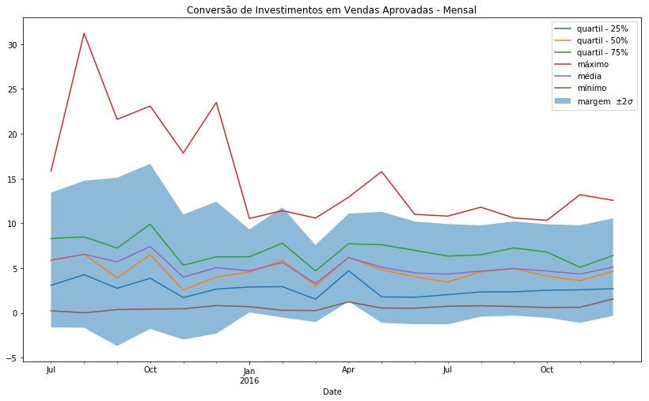

```python
describe_simple_plot (indicator_medias[media][1][period][sumary][base, output], indicator_title);
```

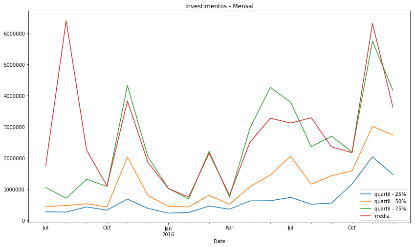

```python
data_table.index.set_levels (sumary_periods[period], level='Date', inplace=True)
describe_simple_plot (data_table.loc[media][base].groupby (level=-1).describe (), base_title,
                      non_extrm_plot_labels)
```

## $\qquad$ Valores negativos nas tabelas

$\qquad$ As ocorrências são confinadas aos canais '0' e '1' e apenas nas colunas de investimentos.

```python
negatives = [[media, brand] for media in Medias for brand in Brands
             if (data_table.loc[media, brand] < 0).any ().any ()]

other_anomalies += negatives
print ('    Canais e marcas com ocorrências de entradas negativas:\n')
print (''.join (('Canal {:d}, marca {:d};\n'.format (media, brand) for media, brand in negatives)))
```

```
    Canais e marcas com ocorrências de entradas negativas:

Canal 0, marca 0;
Canal 0, marca 1;
Canal 0, marca 2;
Canal 1, marca 1;
```

Segue uma amostra da anomalia:

```python
media, brand = 0, 1
data_table.loc (axis=0)[media, brand, Dates[neg_periods[media, brand]], :]
```

| Media | Brand | Date | Investment | NumVisits | NumUniqueVisits | GrossSalesEstimate | GrossSalesPlaced | GrossSalesApproved | QtyOrdersPlaced | QtyOrdersApproved |
| --- | --- | --- | --- | --- | --- | --- | --- | --- | --- | --- |
| 0 | 1 | 2016-01-01 | -1.587458e+06 | 405860.0 | 169288.0 | 19546811.68 | 40833426.48 | 19546811.68 | 62568.0 | 35200.0 |
|  |  | 2016-02-01 | -1.087795e+06 | 438284.0 | 187236.0 | 12955052.88 | 21356526.40 | 12955052.88 | 53416.0 | 36344.0 |
|  |  | 2016-03-02 | -2.909772e+06 | 309778.0 | 102802.0 | 7721608.40 | 17283968.24 | 7721608.40 | 35728.0 | 21472.0 |
|  |  | 2016-05-04 | -2.423986e+06 | 546280.0 | 222082.0 | 28014887.12 | 44165069.52 | 28014887.12 | 75944.0 | 49456.0 |
|  |  | 2016-11-12 | -5.532825e+06 | 468958.0 | 155792.0 | 29539928.88 | 48859016.80 | 29539928.88 | 89848.0 | 60544.0 |

## $\quad$ Viabilidade dos Indicadores

$\qquad$ As ocorrências dessa anomalia são esparsas. Numa inspeção mais cuidadosa, nota-se o seguinte padrão:

$\qquad$ Se tais valores de investimentos são convertidos para valores positivos, tornam-se valores de investimento dentro das margens dos demais valores de investimento.

$\qquad$ Assim sendo, corrige-se os valores da tabela para valores positivos e calcula-se todos os indicadores.

Trecho corrigido:

```python
media, brand = 0, 1
data_table.loc (axis=0)[media, brand, Dates[neg_periods[media, brand]], :]
```

| Media | Brand | Date | Investment | NumVisits | NumUniqueVisits | GrossSalesEstimate | GrossSalesPlaced | GrossSalesApproved | QtyOrdersPlaced | QtyOrdersApproved |
| --- | --- | --- | --- | --- | --- | --- | --- | --- | --- | --- |
| 0 | 1 | 2016-01-01 | 1.587458e+06 | 405860.0 | 169288.0 | 19546811.68 | 40833426.48 | 19546811.68 | 62568.0 | 35200.0 |
|  |  | 2016-02-01 | 1.087795e+06 | 438284.0 | 187236.0 | 12955052.88 | 21356526.40 | 12955052.88 | 53416.0 | 36344.0 |
|  |  | 2016-03-02 | 2.909772e+06 | 309778.0 | 102802.0 | 7721608.40 | 17283968.24 | 7721608.40 | 35728.0 | 21472.0 |
|  |  | 2016-05-04 | 2.423986e+06 | 546280.0 | 222082.0 | 28014887.12 | 44165069.52 | 28014887.12 | 75944.0 | 49456.0 |
|  |  | 2016-11-12 | 5.532825e+06 | 468958.0 | 155792.0 | 29539928.88 | 48859016.80 | 29539928.88 | 89848.0 | 60544.0 |

Segue uma amostra dos indicadores para o canal '1':

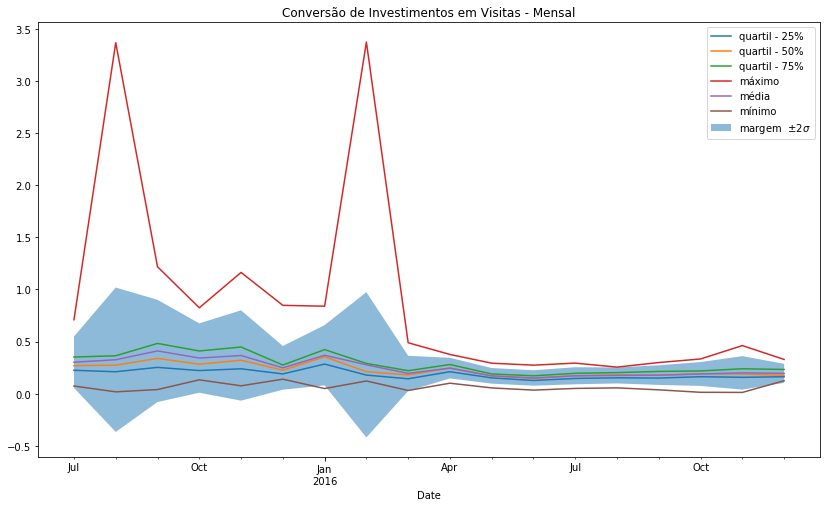

```python
describe_simple_plot (indicator_medias[media][1][period][sumary][base, output], indicator_title);
```

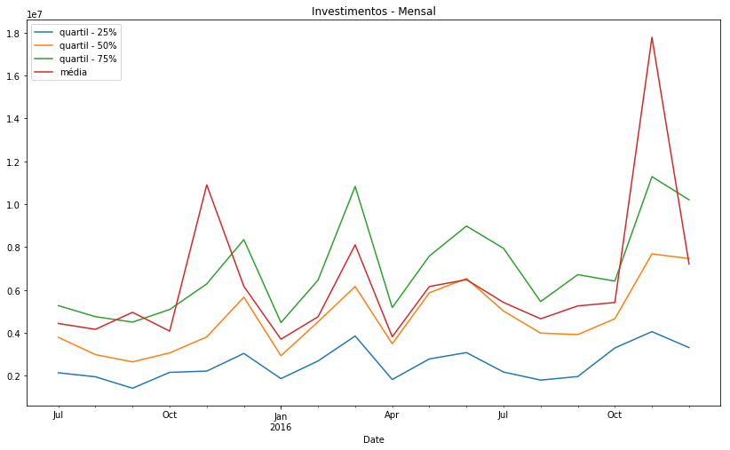

```python
data_table.index.set_levels (sumary_periods[period], level='Date', inplace=True)
describe_simple_plot (data_table.loc[media][base].groupby (level=-1).describe (), base_title,
                      non_extrm_plot_labels)
```

# $\quad$ Após esse processo de tratamento, restam apenas as estatísticas dos dados não-anômalos.

```python
no_anomalies = [[media, brand] for media in Medias for brand in Brands
               if [media, brand] not in treated_anomalies]
print ('    Canais e marcas sem ocorrências de anomalias:\n')
print (''.join (('Canal {:d}, marca {:d};\n'.format (media, brand) for media, brand in no_anomalies)))
```

```
    Canais e marcas sem ocorrências de anomalias:

Canal 3, marca 0;
Canal 3, marca 1;
Canal 3, marca 2;
```

$\qquad$ Isto é, apenas do canal 3.

Segue adiante uma amostra de seus indicadores:

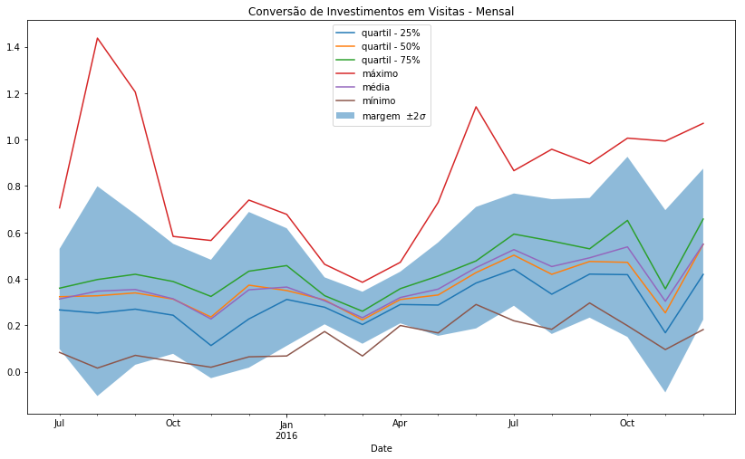

```python
describe_simple_plot (indicator_medias[media][1][period][sumary][base, output], indicator_title);
```

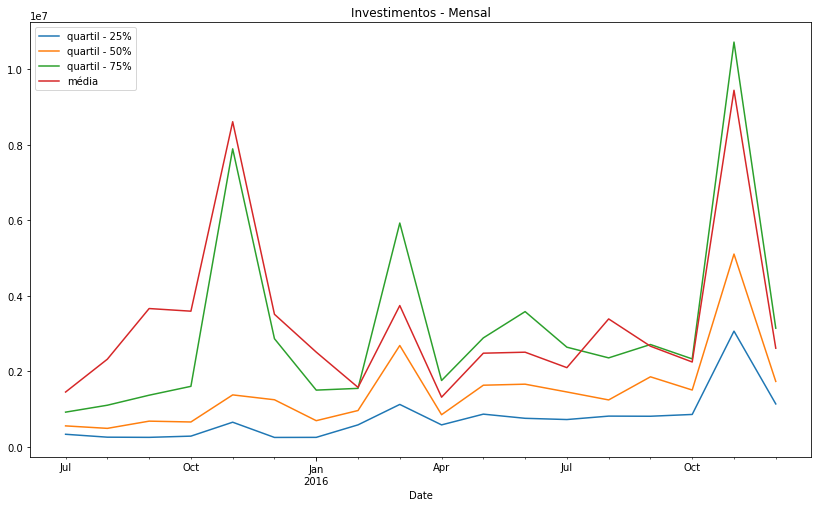

```python
data_table.index.set_levels (sumary_periods[period], level='Date', inplace=True)
describe_simple_plot (data_table.loc[media][base].groupby (level=-1).describe (), base_title,
                      non_extrm_plot_labels)
```

# $\quad$ Análise e comparações

$\qquad$ Realizado o tratamento dos dados e em mãos das tabelas de estatísticas de indicadores, comparativos podem ser estabelecidos entre os desempenhos de cada canal e cada marca.

```python
print ('    Canais disponíves para análise:\n')
print (''.join (('{:d}, '.format (key) for key in indicator_medias.keys ())))
```

```
    Canais disponíves para análise:

2, 4, 5, 6, 7, 0, 1, 3,
```

## $\qquad$ Indicador de Vendas por Visita

$\qquad$ Nos termos desta análise, conversão de Número de visitas em vendas aprovadas. Quantifica a capacidade bruta do canal de converter uma visitação em vendas para o canal. Não quantifica diretamente o retorno, mas pode ser visto como potencial para. Além disso está disponível para todos os canais exceto '8' e '9'.

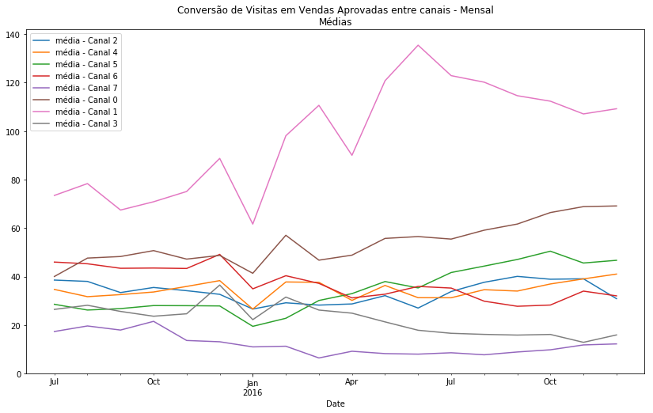

```python
fig = figure (figsize=(14, 8))
ax = fig.gca ()

for media in indicator_medias.keys ():
    media_statisctics = indicator_medias[media][1][period][sumary][base, output]

#     cmp_plot_labels = {'50%': 'quartil - 50% - Canal {:d}'.format (media) ,
#                        'mean': 'média - Canal {:d}'.format (media)}

    cmp_plot_labels = {'mean': 'média - Canal {:d}'.format (media)}

    describe_simple_plot (media_statisctics, indicator_title, cmp_plot_labels, ax)
```

$\qquad$ Em termos de tendência média, o canal '1' sobrepuja significativamente os demais. Todavia, apesar da margem vasta, vale a pena estudar a volatilidade durante o período. Isso dado que, fora o canal '1', as têndecias dos demais canais são próximas, relativamente. Portanto, a variância torna-se um fator de escolha relevante, pois dita o risco envolvido na escolha.

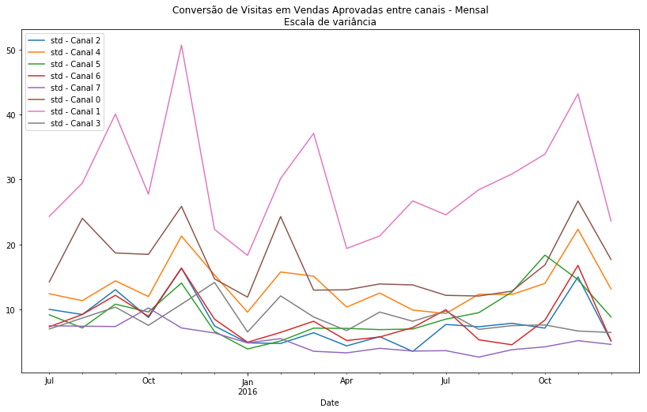

```python
fig = figure (figsize=(14, 8))
ax = fig.gca ()

for media in indicator_medias.keys ():

    media_statisctics = indicator_medias[media][1][period][sumary][base, output]

    cmp_plot_labels = {'std': 'std - Canal {:d}'.format (media)}

    describe_simple_plot (media_statisctics, indicator_title, cmp_plot_labels, ax, non_margin_std=True)
```

$\qquad$ A volatilidade do canal '1', assim como sua tendência média, estão numa escala diferente das demais, portanto, o potencial de retorno é deveras distinto das demais. Para que haja clareza no comparativo entre os menores, a volatilidade do canal '1' será omitida.

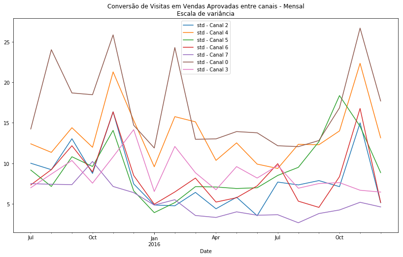

```python
fig = figure (figsize=(14, 8))
ax = fig.gca ()

for media in indicator_medias.keys ():

    if media == 1:

        continue

    media_statisctics = indicator_medias[media][1][period][sumary][base, output]

    cmp_plot_labels = {'std': 'std - Canal {:d}'.format (media)}

    describe_simple_plot (media_statisctics, indicator_title, cmp_plot_labels, ax, non_margin_std=True)
```

$\qquad$ De fato, ainda que os gráficos sejam crus, nota-se eventos não trivias quanto a volatilidade. O canal '0', que possui das melhores tendências médias, também possui das maiores volatilidades. Já o canal 6, bem próximo, possui das menores.

$\qquad$ Numa inspeção mais cuidadosa, mas ainda qualitativa, até janeiro de 2016, o canal '6' compensara em volatilidade se comparado ao '0'. No entanto, mais para o fim de 2016, mesmo com alta volatilidade, o canal '0' passava a compensar devido a têndencia superior. Ou seja, nesse caso, mesmo sob uma escolha mais conservadora, a volatilidade compensa para o canal '0'.

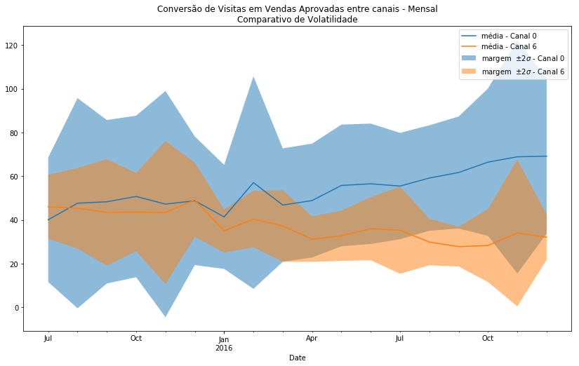

```python
fig = figure (figsize=(14, 8))
ax = fig.gca ()

sigma_multiple = 2

for media in [0, 6]:
    media_statisctics = indicator_medias[media][1][period][sumary][base, output]

    cmp_plot_labels = {'mean': 'média - Canal {:d}'.format (media),
                       'std': 'margem  $\pm{:d}\sigma$ - Canal {:d}'.format (sigma_multiple, media)}

    describe_simple_plot (media_statisctics, indicator_title, cmp_plot_labels, ax)
```

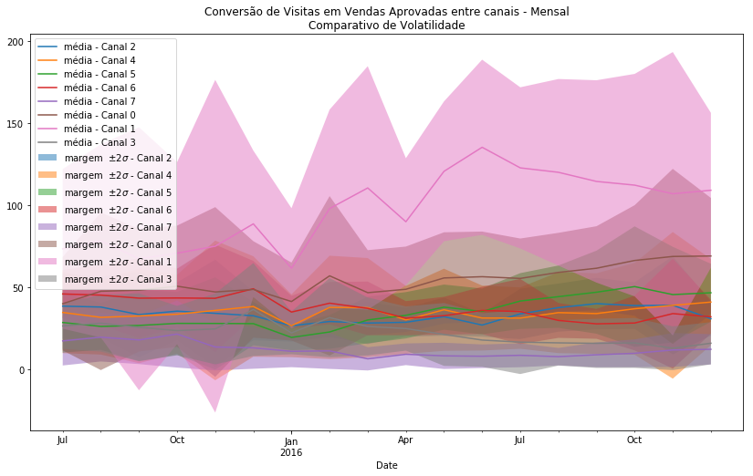

```python
fig = figure (figsize=(14, 8))
ax = fig.gca ()

sigma_multiple = 2

for media in indicator_medias.keys ():
    media_statisctics = indicator_medias[media][1][period][sumary][base, output]

    cmp_plot_labels = {'mean': 'média - Canal {:d}'.format (media),
                       'std': 'margem  $\pm{:d}\sigma$ - Canal {:d}'.format (sigma_multiple, media)}

    describe_simple_plot (media_statisctics, indicator_title, cmp_plot_labels, ax)
```